# SML1 Final Project

# February 27, 2017

The Winton dataset contains numerous predictors which we could choose from in building models. However, our test dataset only contains predictors Ret_2 through Ret_120, so while we could include other data from the Winton training dataset, it would be of no value when testing the model on the test dataset. Therefore, we restrict our possible predictors to Ret_2 through Ret_120 (and transformations or derivations of those predictors).

With so many predictors, and a signficiant deal of noise in the predictors, several of the approaches we took in previous attempts at building models (particularly in Assignments 4 and 5) utilized dimensionality reduction and smoothing techniques. The results from these approaches were disappointing, to say the least. A model submitted for Assignment 5 performed worse than the naive submission upon creating our Kaggle account in Assignment 1. The model used principal components analysis (PCA) to attempt to reduce the number of predictors, and then used smoothing splines on the factors that explained 95% of the total variance as predictors for a general additive model (GAM).

One transformation we considered across models in an effort to work around the low signal-to-noise problem was simply considering the sign of the predictor, rather than the actual numerical quantity of the predictor. That is, we wrote a function that transformed our training set to take the value 1 if any given element was positive, and 0 otherwise. We then used this dataset as our training data for several models. This transformation appeared to retain quite a bit of informational value; for instance, when comparing our random forest model on the untransformed training set to the random forest model fit to the binary training set, the binary random forest model performed worse, but not extremely so. In fact, it managed to explain roughly 2/3rds of the variance that the random forest fit to the untransformed dataset did (10% vs 16% variance explained, respectively, as can be seen below in the Random Forest section). Ultimately, we elected to proceed with the random forest model fit to the untransformed dataset, but it was interesting that the models were not as far apart as one might initially expect.

```r
suppressWarnings(library(readr))
train <- read_csv("C:/Users/cgomo/Downloads/train.csv/train.csv")
fullrow = rep(FALSE,nrow(train))
for (i in 1:nrow(train)) {fullrow[i] = !any(is.na(train[i, 29:147]))}

clean_train <- subset(cbind(train[,29:147],train$Ret_PlusOne,fullrow),fullrow)
colnames(clean_train)[120]<-"Ret_PlusOne"
```

```r
convbin = function (x) {ifelse(x > 0, 1, 0)}
clean_train_bin <- cbind(convbin(clean_train[,1:119]),clean_train$Ret_PlusOne)
colnames(clean_train_bin)[120]<-"Ret_PlusOne"
```

```r
svarnames <- c(paste("Ret_", 2:120, sep = ""))
modform = as.formula(paste("Ret_PlusOne ~ ",paste(svarnames,collapse = "+")))
```

```r
library(repr)

# Change plot size to 3 x 3
options(repr.plot.width=3, repr.plot.height=3)
```

```r
ConvertSubmission = function(mypreds, outfname="mysubmission.txt",
      fullrowfile = "http://www.stat.cmu.edu/~cschafer/MSCF/fullrowtest.txt")
{
  fullrowtest = scan(fullrowfile,sep=",",quiet=TRUE)

  if(length(mypreds) != sum(fullrowtest))
  {
    stop("Your vector of predictions is not the correct length.")
  }
  if(mode(mypreds) != "numeric")
  {
    stop("Your vector of predictions is not of the correct type.")
  }

  write.table("Id,Predicted",file=outfname,sep=",",row.names=F,col.names=F,quote=F)
  pos = 1
  for(i in 1:length(fullrowtest))
  {
     rowlabels = paste(i,"_",1:62,sep="")
     holdout = data.frame(rowlabels,rep(0,62))
     if(fullrowtest[i] == 1)
     {
       holdout[61,2] = mypreds[pos]
       pos = pos + 1
     }
     write.table(holdout, file=outfname, sep=",",
          row.names=F,col.names=F,quote=F,append=TRUE)
   }
}
```

# Linear Model (LASSO)

```r
library(glmnet)

# dataframe for predictors
preddf = as.matrix(clean_train[,1:119])
# create a separate data structure for RetPlusOne here
retmat = as.matrix(clean_train$Ret_PlusOne)

lassomod = glmnet(preddf, retmat, family = "gaussian")
```

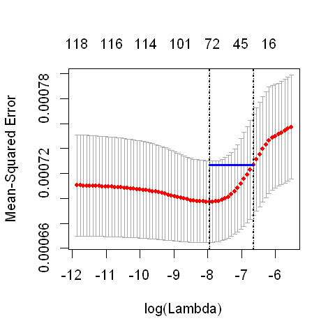

```r
set.seed(17)
cvlassomod = cv.glmnet(preddf, retmat, nfolds = 10)
holdpos = which(cvlassomod$glmnet.fit$lambda == cvlassomod$lambda.1se)

plot(cvlassomod)
abline(v=log(cvlassomod$lambda.min),lty=3,lwd=2)
abline(v=log(cvlassomod$lambda.1se),lty=3,lwd=2)

lines(c(log(cvlassomod$lambda.min),log(cvlassomod$lambda.1se)),
      c(rep(cvlassomod$cvm[holdpos],2)),lwd=3,col=4,lty=1)
```

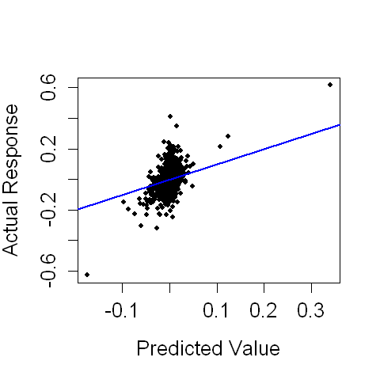

```r
lassopreds = predict(lassomod, preddf, s = 0.0013)
plot(lassopreds, clean_train$Ret_PlusOne, pch=16, cex=0.7,
   xlab="Predicted Value", ylab="Actual Response", cex.axis=1.3,
   cex.lab=1.3)
abline(0,1,lwd=2,col=4)
```

# Additive Model

```r
#run PCA to reduce factors, work only with factors that contribute to 1%+ variance
#explained
dfpca = NULL
pcaout <- princomp(clean_train[,1:119])
for (i in 1:107)
{
  dfpca = cbind(dfpca,pcaout$scores[,i])
}

dffpca <- data.frame(dfpca)
pcavarnames <- c(paste("PCA_", 1:107, sep = ""))
colnames(dffpca) <- pcavarnames
dffpca$Ret_PlusOne <- clean_train$Ret_PlusOne
```

```r
# Now smooth PCA factors to see if this helps
library(mgcv)
gamvarnames <- c(paste("s(PCA_", 1:107, ")", sep = ""))
modform = as.formula(paste("Ret_PlusOne ~ ",paste(gamvarnames,collapse = "+")))
pcagammod = gam(modform, data = dffpca)
```

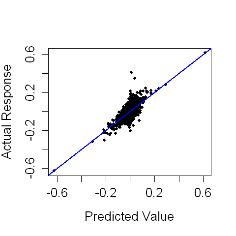

```r
plot(predict(pcagammod),clean_train$Ret_PlusOne,pch=16,cex=0.7,xlab="Predicted Value",
   ylab="Actual Response", cex.axis=1.3,cex.lab=1.3)
abline(0,1,lwd=2,col=4)
```

# Random Forest Model

```r
library(randomForest)
set.seed(17)
randformod = randomForest(modform, data=clean_train, ntree=300, importance=TRUE)
```

We are choosing the random forest model fit on the entire set of untransformed predictors to be our final model. We chose the random forest for several reasons. First, random forests tend to be fairly resilient to the perils of overfitting. Overfitting is a significant concern on this dataset due to the low signal-to-noise ratio. If we have a model that overfits on the training data, it will be fitting too much of the noise, and will likely have very poor out-of-sample performance. In fact, we believe this is partially what contributed to the poor performance of our GAM model when it was submitted to Kaggle. So, in choosing a random forest, we hope the methodology itself will help prevent overfitting. Additionally, by using untransformed predictors, we are keeping the model "simple". Stacking models on models might be intellectually satisfying, but again, our concerns around the amount of noise in the predictors suggests to us that we should endeavor to keep models simple. Below we present diagnostic plots for the model, and we will comment below each plot.

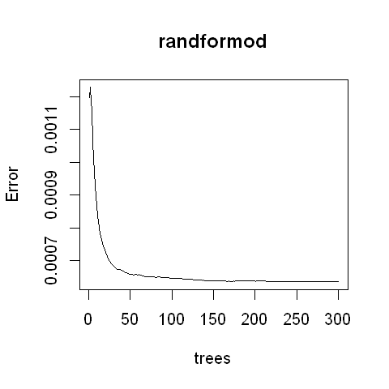

```r
plot(randformod)
```

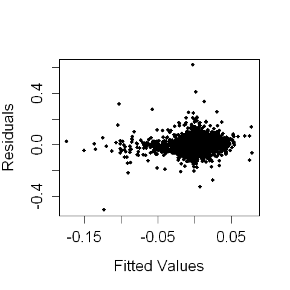

```r
residsrfmod = clean_train$Ret_PlusOne - predict(randformod)

plot(predict(randformod), residsrfmod, xlab="Fitted Values",
   ylab="Residuals", cex.axis=1.3, cex.lab=1.3, pch=16, cex=0.7)
```

There are a few points on this plot that might be somewhat concerning, but overall this seems acceptable. There's certainly nothing that would suggest a pattern in the residuals that would imply a strong violation of modeling assumptions.

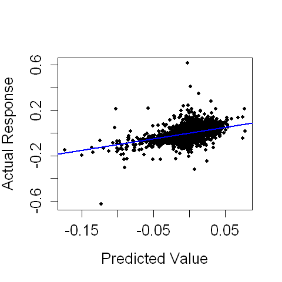

```r
plot(predict(randformod), clean_train$Ret_PlusOne, pch=16, cex=0.7,
   xlab="Predicted Value", ylab="Actual Response", cex.axis=1.3,
   cex.lab=1.3)
abline(0,1,lwd=2,col=4)
```

The fit of this model appears to be acceptable. There are a few points that lie quite far from the line of fit, but overall this seems like a decent fit.

```r
print(randformod)
```

```
Call:
 randomForest(formula = modform, data = clean_train, ntree = 300,      importance = TRUE)
               Type of random forest: regression
                     Number of trees: 300
No. of variables tried at each split: 39

          Mean of squared residuals: 0.0006353827
                    % Var explained: 16.1
```

```
mtry = 39  OOB error = 0.0006650147
Searching left ...
mtry = 20 	OOB error = 0.0006784663
-0.02022746 0.05
Searching right ...
mtry = 78 	OOB error = 0.0006653331
-0.0004787162 0.05
   mtry     OOBError
20   20 0.0006784663
39   39 0.0006650147
78   78 0.0006653331
```

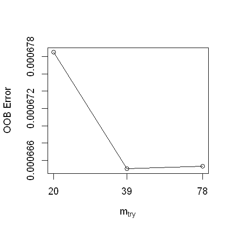

```r
#attempt tuning now
xmat = clean_train[,1:119]
print(tuneRF(xmat,clean_train$Ret_PlusOne))
```

The tuning procedure suggests that the value of m used in our model was the optimal choice.

```r
# create file for Kaggle submission of final model
testsetsub <- read_csv("C:/Users/cgomo/Downloads/testsetsub.csv")
rfpreds = predict(randformod, testsetsub)
ConvertSubmission(rfpreds, outfname="rfsubmission.txt")
```

```r
# write out final model predictions for submission
write.table(rfpreds, file="cgomon.txt", sep="\n", row.names=FALSE, col.names=FALSE)
```

# Random Forest Model (on binary data)

Note that this section is not the final model, but we thought the test we performed on fitting a random forest using the binary transformed predictors was interesting, so it is included below.

```r
set.seed(17)
randformodbin = randomForest(modform, data=clean_train_bin, ntree=300, importance=TRUE)
```

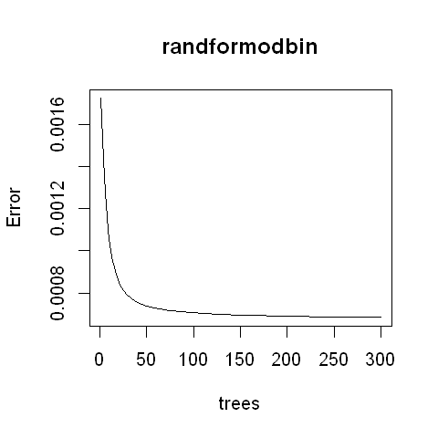

```r
plot(randformodbin)
```

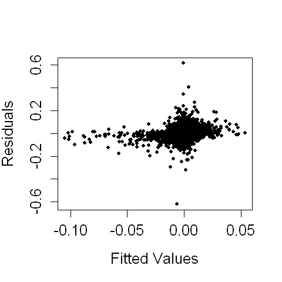

```r
residsrfmodbin = clean_train_bin[,120] - predict(randformodbin)

plot(predict(randformodbin), residsrfmodbin, xlab="Fitted Values",
   ylab="Residuals", cex.axis=1.3, cex.lab=1.3, pch=16, cex=0.7)
```

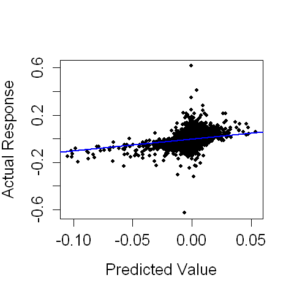

```r
plot(predict(randformodbin), clean_train_bin[,120], pch=16, cex=0.7,
   xlab="Predicted Value", ylab="Actual Response", cex.axis=1.3,
   cex.lab=1.3)
abline(0,1,lwd=2,col=4)
```

```r
print(randformodbin)
```

```
Call:
 randomForest(formula = modform, data = clean_train_bin, ntree = 300,      importance = TRUE)
               Type of random forest: regression
                     Number of trees: 300
No. of variables tried at each split: 39

          Mean of squared residuals: 0.0006831977
                    % Var explained: 9.79
```

```r
rfbinpreds = predict(randformodbin, testsetsub)
ConvertSubmission(rfbinpreds, outfname="rfbinsubmission.txt")
```

# Kaggle Submission

[figure not shown]

# Final Thoughts

Our final model performed the best of the models we submitted throughout the quarter, but failed to outperform the "zero submission" on both the Public Score and Private Score criterion. It would be interesting to see if performance of a random forest model would improve upon the inclusion of different types of predictors other than returns, such as the Features predictors.